# **Cyber Security**

## **Problem Statement**

Book-My-Show will enable the ads on their website, but they are also very cautious about their user privacy and information who visit their website. Some ads URL could contain a malicious link that can trick any recipient and lead to a malware installation, freezing the system as part of a ransomware attack or revealing sensitive information. Book-My-Show now wants to analyze that whether the particular URL is prone to phishing (malicious) or not.

###### Dataset Details:

The input dataset contains an 11k sample corresponding to the 11k URL. Each sample contains 32 features that give a different and unique description of URL ranging from -1,0,1.

-1: Phishing; 0: Suspicious; 1: Legitimate

The sample could be either legitimate or phishing.

#### Project Task: Week 1

###### Exploratory Data Analysis:

1.Each sample has 32 features ranging from -1,0,1. Explore the data using histogram, heatmaps.

```python
import pandas as pd

df_train = pd.read_csv('dataset.csv')
df_train.head()
```

|  | index | having_IPhaving_IP_Address | URLURL_Length | Shortining_Service | having_At_Symbol | double_slash_redirecting | Prefix_Suffix | having_Sub_Domain | SSLfinal_State | Domain_registeration_length | ... | popUpWidnow | Iframe | age_of_domain | DNSRecord | web_traffic | Page_Rank | Google_Index | Links_pointing_to_page | Statistical_report | Result |
| --- | --- | --- | --- | --- | --- | --- | --- | --- | --- | --- | --- | --- | --- | --- | --- | --- | --- | --- | --- | --- | --- |
| 0 | 1 | -1 | 1 | 1 | 1 | -1 | -1 | -1 | -1 | -1 | ... | 1 | 1 | -1 | -1 | -1 | -1 | 1 | 1 | -1 | -1 |
| 1 | 2 | 1 | 1 | 1 | 1 | 1 | -1 | 0 | 1 | -1 | ... | 1 | 1 | -1 | -1 | 0 | -1 | 1 | 1 | 1 | -1 |
| 2 | 3 | 1 | 0 | 1 | 1 | 1 | -1 | -1 | -1 | -1 | ... | 1 | 1 | 1 | -1 | 1 | -1 | 1 | 0 | -1 | -1 |
| 3 | 4 | 1 | 0 | 1 | 1 | 1 | -1 | -1 | -1 | 1 | ... | 1 | 1 | -1 | -1 | 1 | -1 | 1 | -1 | 1 | -1 |
| 4 | 5 | 1 | 0 | -1 | 1 | 1 | -1 | 1 | 1 | -1 | ... | -1 | 1 | -1 | -1 | 0 | -1 | 1 | 1 | 1 | 1 |

5 rows × 32 columns

```python
df_train.describe()
```

|  | index | having_IPhaving_IP_Address | URLURL_Length | Shortining_Service | having_At_Symbol | double_slash_redirecting | Prefix_Suffix | having_Sub_Domain | SSLfinal_State | Domain_registeration_length | ... | popUpWidnow | Iframe | age_of_domain | DNSRecord | web_traffic | Page_Rank | Google_Index | Links_pointing_to_page | Statistical_report | Result |
| --- | --- | --- | --- | --- | --- | --- | --- | --- | --- | --- | --- | --- | --- | --- | --- | --- | --- | --- | --- | --- | --- |
| count | 11055.000000 | 11055.000000 | 11055.000000 | 11055.000000 | 11055.000000 | 11055.000000 | 11055.000000 | 11055.000000 | 11055.000000 | 11055.000000 | ... | 11055.000000 | 11055.000000 | 11055.000000 | 11055.000000 | 11055.000000 | 11055.000000 | 11055.000000 | 11055.000000 | 11055.000000 | 11055.000000 |
| mean | 5528.000000 | 0.313795 | -0.633198 | 0.738761 | 0.700588 | 0.741474 | -0.734962 | 0.063953 | 0.250927 | -0.336771 | ... | 0.613388 | 0.816915 | 0.061239 | 0.377114 | 0.287291 | -0.483673 | 0.721574 | 0.344007 | 0.719584 | 0.113885 |
| std | 3191.447947 | 0.949534 | 0.766095 | 0.673998 | 0.713598 | 0.671011 | 0.678139 | 0.817518 | 0.911892 | 0.941629 | ... | 0.789818 | 0.576784 | 0.998168 | 0.926209 | 0.827733 | 0.875289 | 0.692369 | 0.569944 | 0.694437 | 0.993539 |
| min | 1.000000 | -1.000000 | -1.000000 | -1.000000 | -1.000000 | -1.000000 | -1.000000 | -1.000000 | -1.000000 | -1.000000 | ... | -1.000000 | -1.000000 | -1.000000 | -1.000000 | -1.000000 | -1.000000 | -1.000000 | -1.000000 | -1.000000 | -1.000000 |
| 25% | 2764.500000 | -1.000000 | -1.000000 | 1.000000 | 1.000000 | 1.000000 | -1.000000 | -1.000000 | -1.000000 | -1.000000 | ... | 1.000000 | 1.000000 | -1.000000 | -1.000000 | 0.000000 | -1.000000 | 1.000000 | 0.000000 | 1.000000 | -1.000000 |
| 50% | 5528.000000 | 1.000000 | -1.000000 | 1.000000 | 1.000000 | 1.000000 | -1.000000 | 0.000000 | 1.000000 | -1.000000 | ... | 1.000000 | 1.000000 | 1.000000 | 1.000000 | 1.000000 | -1.000000 | 1.000000 | 0.000000 | 1.000000 | 1.000000 |
| 75% | 8291.500000 | 1.000000 | -1.000000 | 1.000000 | 1.000000 | 1.000000 | -1.000000 | 1.000000 | 1.000000 | 1.000000 | ... | 1.000000 | 1.000000 | 1.000000 | 1.000000 | 1.000000 | 1.000000 | 1.000000 | 1.000000 | 1.000000 | 1.000000 |
| max | 11055.000000 | 1.000000 | 1.000000 | 1.000000 | 1.000000 | 1.000000 | 1.000000 | 1.000000 | 1.000000 | 1.000000 | ... | 1.000000 | 1.000000 | 1.000000 | 1.000000 | 1.000000 | 1.000000 | 1.000000 | 1.000000 | 1.000000 | 1.000000 |

8 rows × 32 columns

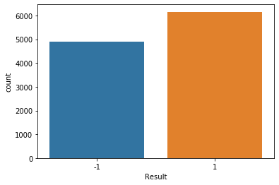

```python
import seaborn as sns

sns.countplot(data=df_train, x='Result')
```

No imbalance oberved in the responses.

```python
del df_train['index']
```

As observed earlier index column is an ID column, revoming it.

```python
df_train_melt = pd.melt(df_train, id_vars=['Result'],
        var_name='Class', value_name='Description')
```

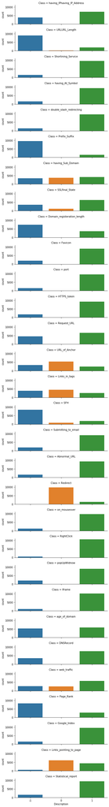

```python
import seaborn as sns

sns.catplot(data=df_train_melt, height=1.5, aspect=4, kind="count",
            x="Description", row="Class")
```

Although some features are oberved to have very imbalanced values, no single value features are observed.

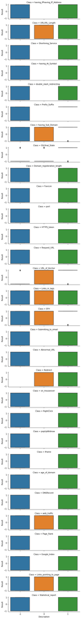

```python
import seaborn as sns

sns.catplot(data=df_train_melt, height=1.5, aspect=4, kind="box",
            x="Description", y="Result", row="Class")
```

As obesrved, some features such as SSLfinal_State and URL_of_Anchor seem to be good predictors

2.Determine the number of samples present in the data, unique elements in all the features.

```python
df_train.shape
```

```
(11055, 31)
```

Same size is 11055.

```python
df_train.nunique()
```

```
having_IPhaving_IP_Address     2
URLURL_Length                  3
Shortining_Service             2
having_At_Symbol               2
double_slash_redirecting       2
Prefix_Suffix                  2
having_Sub_Domain              3
SSLfinal_State                 3
Domain_registeration_length    2
Favicon                        2
port                           2
HTTPS_token                    2
Request_URL                    2
URL_of_Anchor                  3
Links_in_tags                  3
SFH                            3
Submitting_to_email            2
Abnormal_URL                   2
Redirect                       2
on_mouseover                   2
RightClick                     2
popUpWidnow                    2
Iframe                         2
age_of_domain                  2
DNSRecord                      2
web_traffic                    3
Page_Rank                      2
Google_Index                   2
Links_pointing_to_page         3
Statistical_report             2
Result                         2
dtype: int64
```

Min unique values among the features is 2, hence no direct exclusion of features here, inline with observation earlier.

3.Check if there is any null value in any features.

```python
df_train.info()
```

```
<class 'pandas.core.frame.DataFrame'>
RangeIndex: 11055 entries, 0 to 11054
Data columns (total 31 columns):
 #   Column                       Non-Null Count  Dtype
---  ------                       --------------  -----
 0   having_IPhaving_IP_Address   11055 non-null  int64
 1   URLURL_Length                11055 non-null  int64
 2   Shortining_Service           11055 non-null  int64
 3   having_At_Symbol             11055 non-null  int64
 4   double_slash_redirecting     11055 non-null  int64
 5   Prefix_Suffix                11055 non-null  int64
 6   having_Sub_Domain            11055 non-null  int64
 7   SSLfinal_State               11055 non-null  int64
 8   Domain_registeration_length  11055 non-null  int64
 9   Favicon                      11055 non-null  int64
```

[output cut: 23 more lines]

```python
df_train.isnull().values.any()
```

```
False
```

No null value is observed.

#### Project Task: Week 2

###### Correlation of features and feature selection:

Next, we have to find if there are any correlated features present in the data. Remove the feature which might be correlated with some threshold.

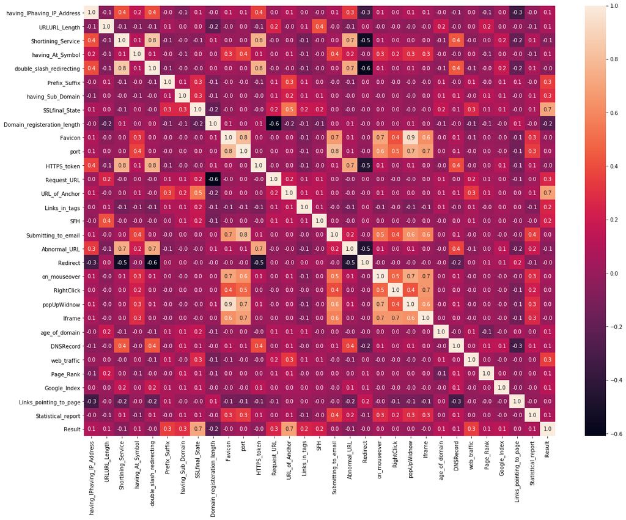

```python
from matplotlib import pyplot as plt
import seaborn as sns

plt.figure(figsize = (20,15))
sns.heatmap(data=df_train.corr(), annot=True, fmt='.1f')
plt.show()
```

Some features are oberved to have high correlation such as popUpWindow and Favicon.

```python
from sklearn.model_selection import train_test_split
from sklearn.preprocessing import StandardScaler
from sklearn.decomposition import PCA

df_y = df_train['Result']
df_x = df_train.drop('Result', axis=1)
x_train, x_test, y_train, y_test = train_test_split(df_x, df_y, test_size=0.3, random_state=123)

sc = StandardScaler()
arr_x_train_scaled = sc.fit_transform(x_train)
arr_x_test_scaled = sc.transform(x_test)
pca = PCA().fit(arr_x_train_scaled)
```

Perform PCA to reduce the features with correlation.

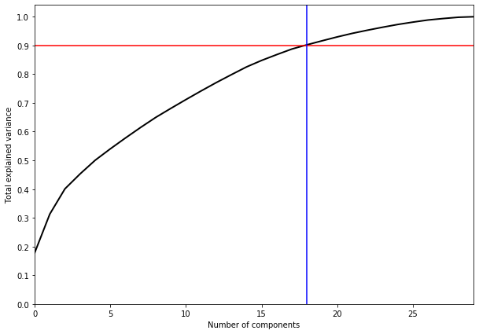

```python
import matplotlib.pyplot as plt
import numpy as np
# Visualize Variance by new Dimensions
plt.figure(figsize=(10,7))

plt.plot(np.cumsum(pca.explained_variance_ratio_), color='k', lw=2)

plt.xlabel('Number of components')
plt.ylabel('Total explained variance')

plt.xlim(0, len(df_x.columns)-1)
plt.yticks(np.arange(0, 1.1, 0.1))

plt.axhline(0.90, c='r')
n_components = 18
plt.axvline(n_components, c='b')

plt.show()
```

Using a 90% variance explanation threshold, 18 components are used for PCA.

```python
pca = PCA(n_components = n_components)
arr_x_train_pca = pca.fit_transform(arr_x_train_scaled)
arr_x_test_pca = pca.transform(arr_x_test_scaled)
```

Perform PCA to reduce the features.

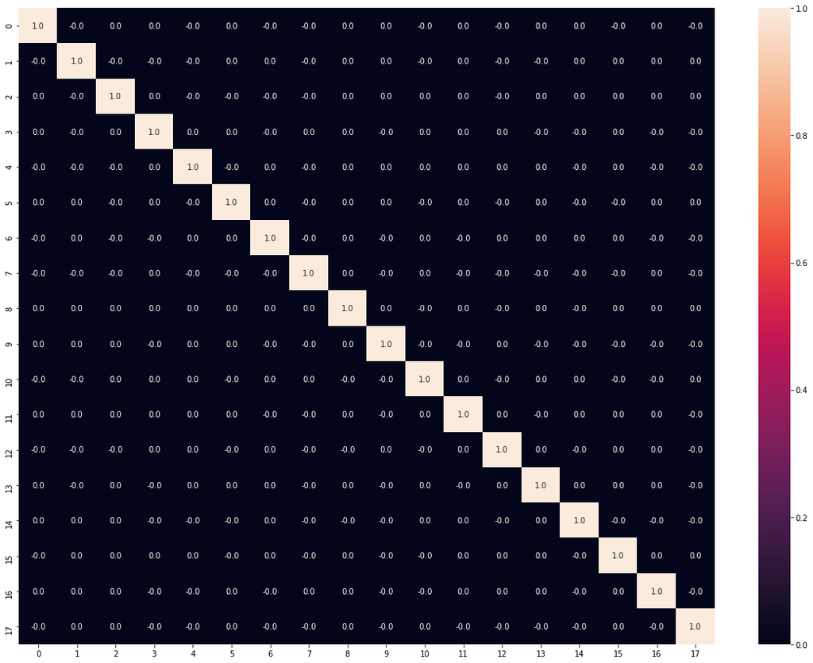

```python
import seaborn as sns
plt.figure(figsize = (20,15))
sns.heatmap(pd.DataFrame(arr_x_train_pca).corr(), annot=True, fmt='.1f')
plt.show()
```

As observed, no correlation is among the PCA reduced features.

#### Project Task: Week 3 and 4

###### Building Classification Model:

Finally, build a robust classification system that classifies whether the URL sample is a phishing site or not.

1.Build classification models using a binary classifier to detect malicious or phishing URLs.

```python
import warnings
import xgboost as xgb
from sklearn.metrics import r2_score

warnings.filterwarnings("ignore", category=UserWarning)

dm_train = xgb.DMatrix(arr_x_train_pca, label = y_train)
dm_valid = xgb.DMatrix(arr_x_test_pca, label = y_test)

xgb_params = {
    'objective': 'binary:logistic',
    'eta': 0.02,
    'max_depth': 4,
}

watchlist = [(dm_train, 'train'), (dm_valid, 'valid')]
model_xgboost = xgb.XGBClassifier(n_estimators=1000, max_depth=4, learning_rate=0.02, objective = 'binary:logistic', eval_metric="logloss")
model_xgboost.fit(X=arr_x_train_pca, y=y_train, eval_set=[(arr_x_test_pca, y_test)], early_stopping_rounds=50,  verbose=10 )
```

```
XGBClassifier(base_score=0.5, booster='gbtree', colsample_bylevel=1,
              colsample_bynode=1, colsample_bytree=1, eval_metric='logloss',
              gamma=0, gpu_id=-1, importance_type='gain',
              interaction_constraints='', learning_rate=0.02, max_delta_step=0,
              max_depth=4, min_child_weight=1, missing=nan,
              monotone_constraints='()', n_estimators=1000, n_jobs=8,
              num_parallel_tree=1, objective='binary:logistic', random_state=0,
              reg_alpha=0, reg_lambda=1, scale_pos_weight=1, subsample=1,
              tree_method='exact', use_label_encoder=True,
              validate_parameters=1, verbosity=None)
```

The first model is build using xgboost.

2.Illustrate the diagnostic ability of this binary classifier by plotting the ROC curve.

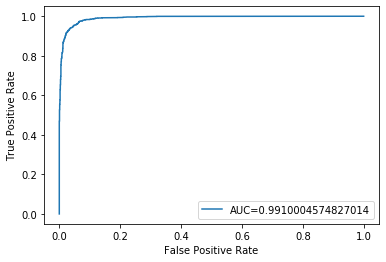

```python
from sklearn import metrics

y_pred_proba = model_xgboost.predict_proba(arr_x_test_pca)[:,1]
fpr, tpr, _ = metrics.roc_curve(y_test,  y_pred_proba)
auc = metrics.roc_auc_score(y_test, y_pred_proba)

#create ROC curve
plt.plot(fpr,tpr,label="AUC="+str(auc))
plt.ylabel('True Positive Rate')
plt.xlabel('False Positive Rate')
plt.legend(loc=4)
plt.show()
```

ROC curve is plotted with AUC around 99.1%.

3.Validate the accuracy of data by the K-Fold cross-validation technique

```python
str_scoring = 'roc_auc' #'accuracy'
```

```python
import warnings
from sklearn.model_selection import KFold
from sklearn.pipeline import make_pipeline
from sklearn.model_selection import cross_val_score

warnings.filterwarnings("ignore", category=UserWarning)

model = make_pipeline(
    StandardScaler(),
    PCA(n_components = n_components),
    xgb.XGBClassifier(learning_rate=0.02, objective='binary:logistic', eval_metric="logloss",
                      max_depth=4, n_estimators=1000)
)
cv = KFold(n_splits=5, random_state=1, shuffle=True)
scores = cross_val_score(model, df_x, df_y, scoring=str_scoring, cv=cv, n_jobs=-1)

print('ROC AUC score mean: %.6f; standard deviation: %.6f' % (np.mean(scores), np.std(scores)))
```

```
ROC AUC score mean: 0.992089; standard deviation: 0.001068
```

5-fold cross-validation performed indicates similar ROC AUC.

4.Apply grid search technique to create different models

```python
from sklearn.pipeline import Pipeline
from sklearn.model_selection import GridSearchCV

pipeline = Pipeline([
    ('model', xgb.XGBClassifier(learning_rate=0.02, objective = 'binary:logistic', eval_metric="logloss"))
])

param_grid = {
    'model__max_depth':[4, 6, 8],
    'model__n_estimators':[500, 1000, 1500],
}

grid = GridSearchCV(pipeline, param_grid, cv=5, scoring=str_scoring,
                    n_jobs=-1, return_train_score=False)
grid.fit(arr_x_train_pca, y_train)

score_mean = grid.cv_results_["mean_test_score"][grid.best_index_]
score_std = grid.cv_results_["std_test_score"][grid.best_index_]

print(f"Best XGBoost parameters: {grid.best_params_}")
print(f"Mean CV score: {score_mean: .6f}")
print(f"Standard deviation of CV score: {score_std: .6f}")

y_pred_proba = grid.best_estimator_.predict_proba(arr_x_test_pca)[:,1]
roc_auc = metrics.roc_auc_score(y_test, y_pred_proba)

print(f"ROC AUC validation score: {roc_auc: .6f}")
```

```
Best XGBoost parameters: {'model__max_depth': 6, 'model__n_estimators': 1500}
Mean CV score:  0.992738
Standard deviation of CV score:  0.001180
ROC AUC validation score:  0.993416
```

```python
from sklearn.pipeline import Pipeline
from sklearn.model_selection import GridSearchCV
from sklearn.neighbors import KNeighborsClassifier

pipeline = Pipeline([
    ('model', KNeighborsClassifier())
])

param_grid = {
    'model__n_neighbors':list(range(1, 31)),
}

grid = GridSearchCV(pipeline, param_grid, cv=5, scoring=str_scoring,
                    n_jobs=-1, return_train_score=False)
grid.fit(arr_x_train_pca, y_train)

score_mean = grid.cv_results_["mean_test_score"][grid.best_index_]
score_std = grid.cv_results_["std_test_score"][grid.best_index_]

print(f"Best KNN parameters: {grid.best_params_}")
print(f"Mean CV score: {score_mean: .6f}")
print(f"Standard deviation of CV score: {score_std: .6f}")

y_pred_proba = grid.best_estimator_.predict_proba(arr_x_test_pca)[:,1]
roc_auc = metrics.roc_auc_score(y_test, y_pred_proba)

print(f"ROC AUC validation score: {roc_auc: .6f}")
```

```
Best KNN parameters: {'model__n_neighbors': 7}
Mean CV score:  0.980971
Standard deviation of CV score:  0.002664
ROC AUC validation score:  0.981238
```

```python
from sklearn.pipeline import Pipeline
from sklearn.model_selection import GridSearchCV
from sklearn.ensemble import RandomForestClassifier

pipeline = Pipeline([
    ('model', RandomForestClassifier())
])

param_grid = {
    'model__bootstrap': [True],
    'model__max_depth': [80, 90, 100, 110],
    'model__max_features': [2, 3],
    'model__min_samples_leaf': [3, 4, 5],
    'model__min_samples_split': [8, 10, 12],
    'model__n_estimators': [100, 200, 300, 1000]
}

grid = GridSearchCV(pipeline, param_grid, cv=5, scoring=str_scoring,
                    n_jobs=-1, return_train_score=False)
grid.fit(arr_x_train_pca, y_train)

score_mean = grid.cv_results_["mean_test_score"][grid.best_index_]
score_std = grid.cv_results_["std_test_score"][grid.best_index_]

print(f"Best RF parameters: {grid.best_params_}")
print(f"Mean CV score: {score_mean: .6f}")
print(f"Standard deviation of CV score: {score_std: .6f}")

y_pred_proba = grid.best_estimator_.predict_proba(arr_x_test_pca)[:,1]
roc_auc = metrics.roc_auc_score(y_test, y_pred_proba)

print(f"ROC AUC validation score: {roc_auc: .6f}")
```

```
Best RF parameters: {'model__bootstrap': True, 'model__max_depth': 100, 'model__max_features': 3, 'model__min_samples_leaf': 3, 'model__min_samples_split': 8, 'model__n_estimators': 300}
Mean CV score:  0.988492
Standard deviation of CV score:  0.002497
ROC AUC validation score:  0.989478
```

```python
from sklearn.pipeline import Pipeline
from sklearn.model_selection import GridSearchCV
from sklearn.svm import SVC

pipeline = Pipeline([
    ('model', SVC(probability=True))
])

param_grid = {
    'model__C': [0.1, 1, 10, 100, 1000],
    'model__gamma': [1, 0.1, 0.01, 0.001, 0.0001],
    'model__kernel': ['rbf']
}

grid = GridSearchCV(pipeline, param_grid, cv=5, scoring=str_scoring,
                    n_jobs=-1, return_train_score=False)
grid.fit(arr_x_train_pca, y_train)

score_mean = grid.cv_results_["mean_test_score"][grid.best_index_]
score_std = grid.cv_results_["std_test_score"][grid.best_index_]

print(f"Best SVM parameters: {grid.best_params_}")
print(f"Mean CV score: {score_mean: .6f}")
print(f"Standard deviation of CV score: {score_std: .6f}")

y_pred_proba = grid.best_estimator_.predict_proba(arr_x_test_pca)[:,1]
roc_auc = metrics.roc_auc_score(y_test, y_pred_proba)

print(f"ROC AUC validation score: {roc_auc: .6f}")
```

```
Best SVM parameters: {'model__C': 100, 'model__gamma': 0.01, 'model__kernel': 'rbf'}
Mean CV score:  0.990736
Standard deviation of CV score:  0.001942
ROC AUC validation score:  0.990286
```

```python
from sklearn.pipeline import Pipeline
from sklearn.model_selection import GridSearchCV
from sklearn.naive_bayes import GaussianNB

pipeline = Pipeline([
    ('model', GaussianNB())
])

param_grid = {
    'model__var_smoothing': np.logspace(0,-9, num=100),
}

grid = GridSearchCV(pipeline, param_grid, cv=5, scoring=str_scoring,
                    n_jobs=-1, return_train_score=False)
grid.fit(arr_x_train_pca, y_train)

score_mean = grid.cv_results_["mean_test_score"][grid.best_index_]
score_std = grid.cv_results_["std_test_score"][grid.best_index_]

print(f"Best Naive Bayes parameters: {grid.best_params_}")
print(f"Mean CV score: {score_mean: .6f}")
print(f"Standard deviation of CV score: {score_std: .6f}")

y_pred_proba = grid.best_estimator_.predict_proba(arr_x_test_pca)[:,1]
roc_auc = metrics.roc_auc_score(y_test, y_pred_proba)

print(f"ROC AUC validation score: {roc_auc: .6f}")
```

```
Best Naive Bayes parameters: {'model__var_smoothing': 0.08111308307896872}
Mean CV score:  0.965615
Standard deviation of CV score:  0.002472
ROC AUC validation score:  0.960789
```

Among the models, XGBoost, SVM and Random Forest showed higher ROC AUC accuracy, followed by KNN and then Gaussian Naive Bayers.